# Fitness Activity Monitoring Project

Alex Tu

Saturday, December 13, 2014

```r
library(knitr)
opts_chunk$set(echo = TRUE, results = "asis")
options(scipen = 1)
```

Read activity data into a data frame:

```r
activity <- read.csv("./activity.csv", header=T, colClasses = c("numeric", "character", "numeric"))
activity$date <- as.Date(activity$date, format="%Y-%m-%d")
```

Plot histogram for daily total number of steps:

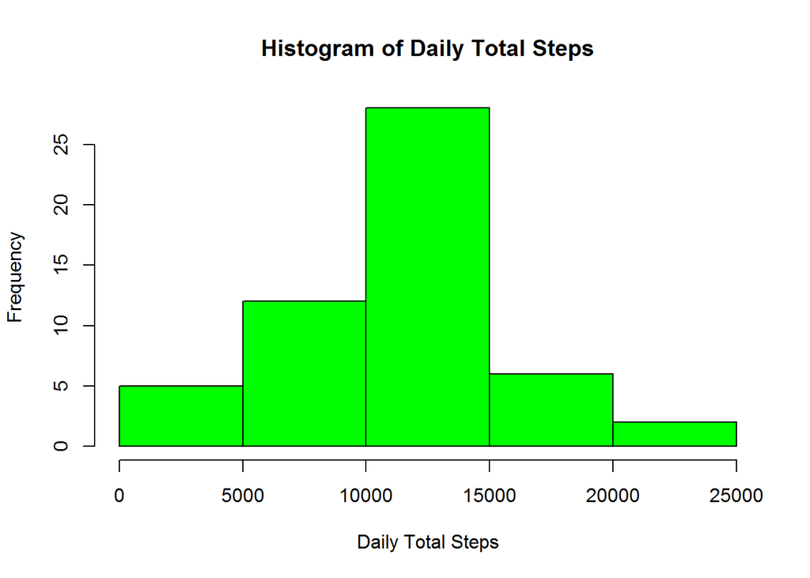

```r
dailytotal <- aggregate(steps ~ date, data=activity, sum)
hist(dailytotal$steps, col = "green", xlab = "Daily Total Steps", main = "Histogram of Daily Total Steps")
```

```r
dev.copy(png, file = "./figure/dailytotalsteps.png")
```

png 3

```r
dev.off()
```

pdf 2

Calculate mean and median for daily total number of steps:

- The mean for daily total number of steps is 10766.
- The median for daily total number of steps is 10765.

Time series plot of 5-minute interval and average number of steps across all days:

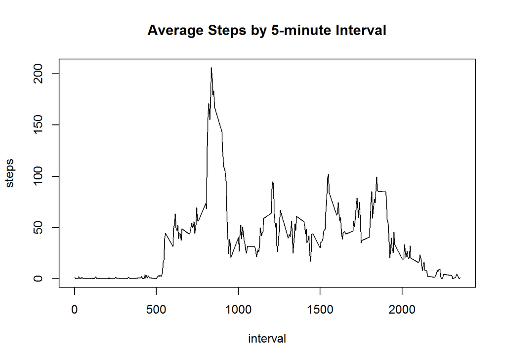

```r
intervalmean <- aggregate(steps ~ interval, data=activity, mean)
with(intervalmean, plot(interval, steps, type = "l", main = "Average Steps by 5-minute Interval"))
```

```r
dev.copy(png, file = "./figure/intervalaveragesteps.png")
```

png 3

```r
dev.off()
```

pdf 2

Calculate 5-minute interval with largest average number of steps:

```r
maxavgrow <- intervalmean[intervalmean$steps == max(intervalmean$steps),]
maxavginterval <- maxavgrow$interval
```

- The 5-minute interval with largest average number of steps is 835.

Calculate number of missing values (coded as “NA”) in dataset:

```r
nacount <- nrow(activity[activity$steps == "NA",])
```

- Total number of missing values: 2304.

Replace missing values (“NA”) with the mean of 5-minute interval:

```r
intervalmean <- aggregate(steps ~ interval, data=activity, mean)
names(intervalmean) <- c("interval", "avgsteps")
activity_intervalmean <- merge(activity, intervalmean)
activity_intervalmean <- activity_intervalmean[order(activity_intervalmean$date),]
activity_intervalmean$steps <- ifelse(is.na(activity_intervalmean$steps),
                                    activity_intervalmean$avgsteps, activity_intervalmean$steps)
activity_imputed <- activity_intervalmean[, 1:3]
```

Plot histogram for daily total number of steps with imputed NA’s:

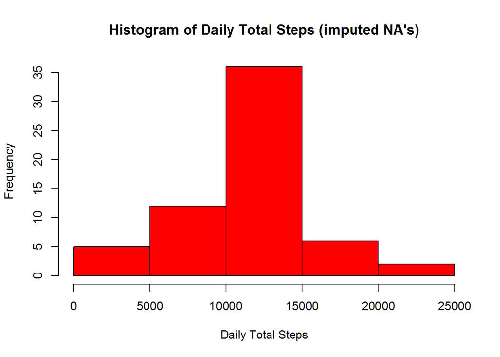

```r
dailytotal_imputed <- aggregate(steps ~ date, data=activity_imputed, sum)
hist(dailytotal_imputed$steps, col = "red", xlab = "Daily Total Steps", main = "Histogram of Daily Total Steps (imputed NA's)")
```

```r
dev.copy(png, file = "./figure/dailytotalsteps_nona.png")
```

png 3

```r
dev.off()
```

pdf 2

Calculate mean and median for daily total number of steps with imputed NA’s:

- The mean for daily total number of steps is 10766.
- The median for daily total number of steps is 10766.
- The mean remain the same at 10766 with NA’s remaining in the data set as compared to 10766 with NA’s being imputed.
- The median increased slightly from 10765 with NA’s remaining in the data set to 10766 with NA’s being imputed.
- With NA’s being removed from the data set, the frequency for daily total of steps in the range 10000-15000 is around 35 which is slightly higher than with NA’s being in the data set which is around 30.

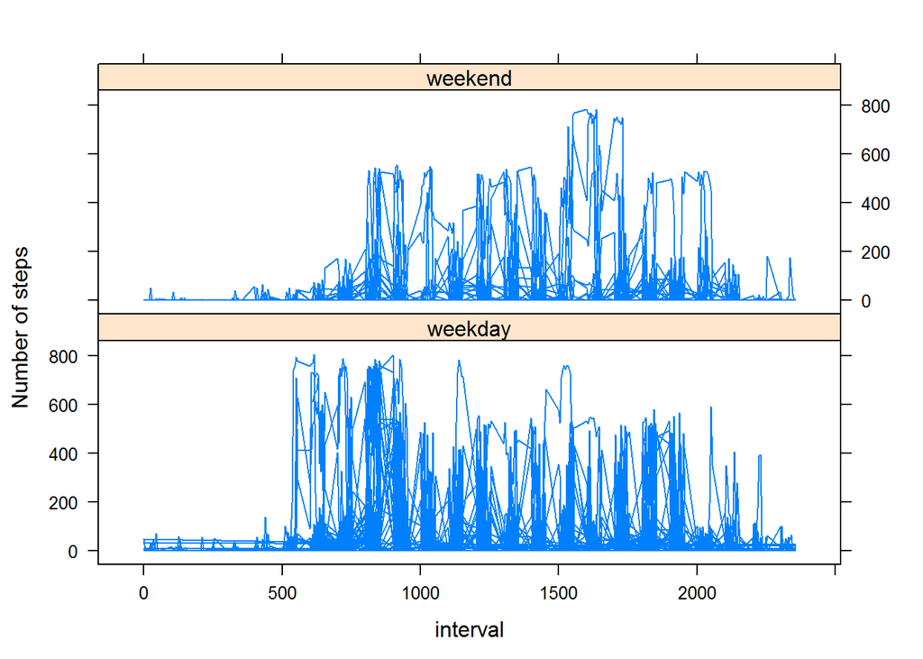

```r
library(lattice)
activity_imputed$date <- as.factor(ifelse(weekdays(activity_imputed$date) %in% c("Saturday","Sunday"), "weekend", "weekday"))
xyplot(activity_imputed$steps ~ activity_imputed$interval  | activity_imputed$date, , type = "l", xlab = "interval", ylab = "Number of steps", layout = c(1, 2))
```

```r
dev.copy(png, file = "./figure/dailytotalsteps_wkdy.png")
```

png 3

```r
dev.off()
```

pdf 2